# HRV analysis

## Detrended Fluctuation analysis

The Detrended Fluctuation Analysis $(DFA)$ has become a widely used technique for detecting long range correlations in time series. The $DFA$ procedure may be summarized as follows:

1. Integrate the time series to be analyzed. The time series resulting from the integration will be referred to as the profile.
2. Divide the profile into $N$ non-overlapping segments.
3. Calculate the local trend for each of the segments using least-square regression. Compute the total error for each of the segments.
4. Compute the average of the total error over all segments and take its root square. By repeating the previous steps for several segment sizes (let’s denote it by $t$), the so-called Fluctuation function $F(t)$ can be obtained.
5. If the data presents long-range power law correlations: $F(t)$ proportional $t^\alpha$ and I may estimate using regression.
6. Usually, when plotting $log{(F(t)}$) Vs $log(t)$ we may distinguish two linear regions. By regression them separately, we obtain two scaling exponents, $\alpha1$ (characterizing short-term fluctuations) and $\alpha2$ (characterizing long-term fluctuations).

```
##  Performing Detrended Fluctuation Analysis
```

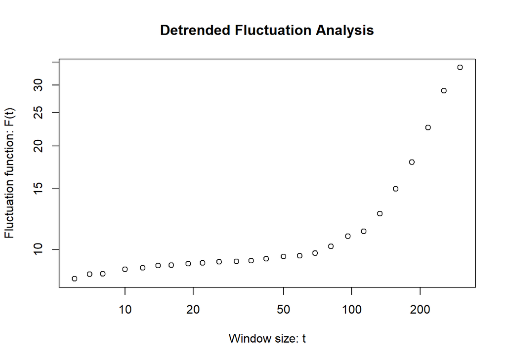

```r
# Calculate the detrended fluctuation analysis alpha 1 and alpha2 parameters
hrv.data = CalculateDFA(hrv.data, indexNonLinearAnalysis = 1, windowSizeRange = c(6,300),
                     npoints = 25, doPlot = TRUE)
```

```
##  Estimating Scaling exponent
```

```
##  Scaling Exponent number 1 = 0.0608
```

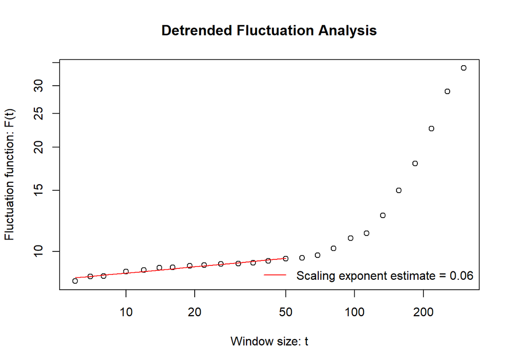

```r
hrv.data = EstimateDFA(hrv.data, indexNonLinearAnalysis = 1,
                    regressionRange = c(5,50), doPlot = TRUE)
```